# Rvis01

Mino

Sunday, January 18, 2015

네이선 아우의 Visualize this 책에 있는 내용 중 R로 실습할 수 있는 내용들을 기준으로 소개하고 일부 내용을 추가하였다

이번 자료에서는 책의 내용들을 위주로 실습하고 이후에는 `ggplot2`, `ggvis` 등 다른 시각화 패키지들을 살펴볼것이다

우리가 시각화할 자료를 크게 **시간**, **분포**, **관계**, **비교**, **공간** 으로 구분하여

각각의 자료에 맞는 다양한 차트를 R로 그리는 방법을 알아보자

# 시간 시각화

## 막대 그래프

일단 데이터를 불러온다

```r
hotdogs = read.csv("http://datasets.flowingdata.com/hot-dog-contest-winners.csv",
                   sep = "," ,
                   header = T)

# 이게 정석이다.
# sep옵션을 통해 자료가 무슨 기호를 통해 구분되는지 명시해주고
# header 옵션을 통해 첫번째 열에 열 이름이 있는지 없는지 알려준다

# 근데 없어도 됨
# 개떡같이말해도 찰떡같이 알아듣는다
# 못알아들으면 알아듣게 해줘야 함

head(read.csv("http://datasets.flowingdata.com/hot-dog-contest-winners.csv") )
```

```
##   Year                       Winner Dogs.eaten       Country New.record
## 1 1980 Paul Siederman & Joe Baldini       9.10 United States          0
## 2 1981              Thomas DeBerry       11.00 United States          0
## 3 1982               Steven Abrams       11.00 United States          0
## 4 1983                 Luis Llamas       19.50        Mexico          0
## 5 1984               Birgit Felden        9.50       Germany          0
## 6 1985             Oscar Rodriguez       11.75 United States          0
```

**year** 연도

**winner** 우승자 이름

**dogs.eaten** 우승자가 먹은 핫도그 수

**country** 우승자 국적

**new.record** 세계기록 경신시 1

간단한 막대그래프를 그려보자

`barplot` 함수를 쓰면 막대그래프를 그릴 수 있다

보통 많이 쓰게 될 `plot`함수의 경우 기본적으로는 산점도(Scatter Plot)을 그리게 된다

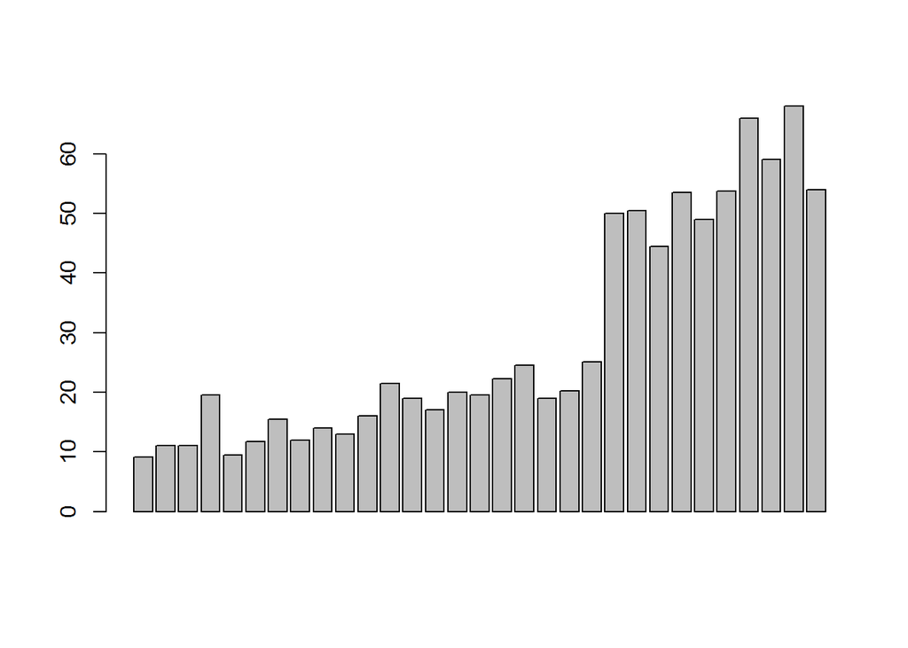

```r
barplot(hotdogs$Dogs.eaten)
```

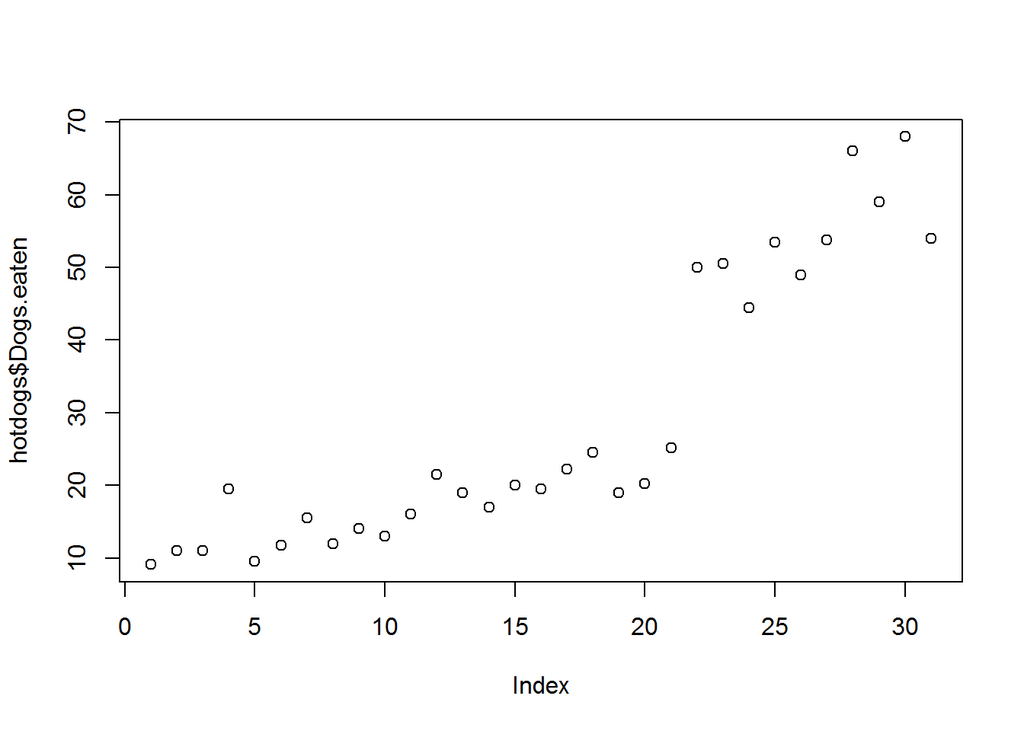

```r
plot(hotdogs$Dogs.eaten)
```

### 막대에 연도 라벨 추가

names.arg 옵션을 추가해서 연도에 해당하는 라벨을 만들 수 있다

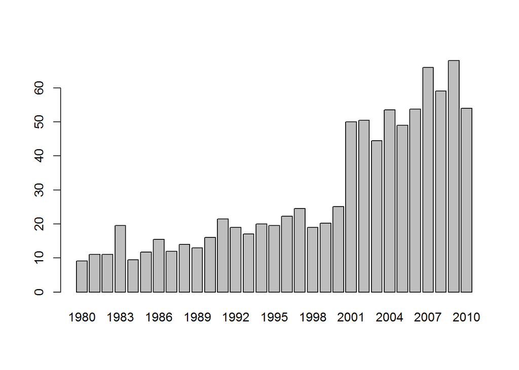

```r
barplot(hotdogs$Dogs.eaten,
        names.arg = hotdogs$Year)
```

### 축의 라벨, 외곽선 설정, 색상

막대기에 색을 넣어보자

`col` 에 빨간색을 넣어보고 외곽선은 없애버린다

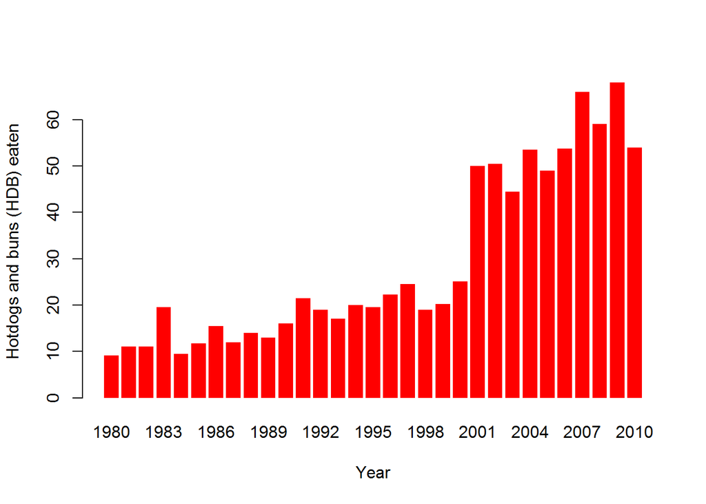

```r
barplot(hotdogs$Dogs.eaten,
        names.arg = hotdogs$Year,
        col = "red",
        border = NA,
        xlab = "Year",
        ylab = "Hotdogs and buns (HDB) eaten")
```

미국인이 우승한 해의 막대와 그렇지 않은 해의 색상을 구분해보자.

색상정보를 담은 리스트 or 벡터를 만들어야 한다

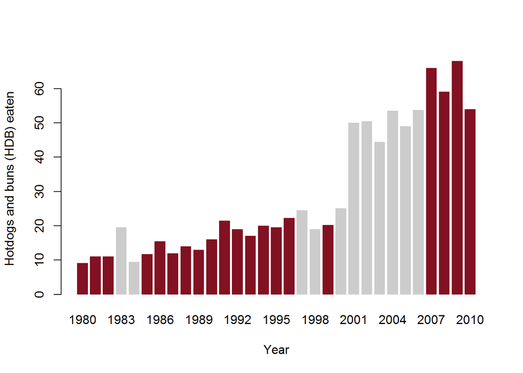

```r
fill_colors = c()

for (i in 1:length(hotdogs$Country)){
  if (hotdogs$Country[i] == "United States"){
      fill_colors = c(fill_colors,"#821122")
  } else {
      fill_colors = c(fill_colors, "#cccccc")
  }

}

barplot(hotdogs$Dogs.eaten,
        names.arg = hotdogs$Year,
        col = fill_colors,
        border = NA,
        xlab = "Year",
        ylab = "Hotdogs and buns (HDB) eaten")
```

`space` 옵션을 통해 막대간격을 조정할 수 있다

`main` 옵션으로는 제목을 설정한다

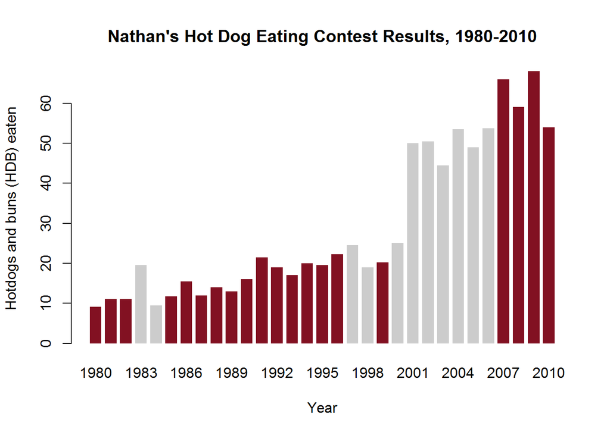

```r
barplot(hotdogs$Dogs.eaten,
        names.arg = hotdogs$Year,
        col = fill_colors,
        border=NA,
        space = 0.3,
        main = "Nathan's Hot Dog Eating Contest Results, 1980-2010",
        xlab = "Year",
        ylab = "Hotdogs and buns (HDB) eaten")
```

## 누적 막대 그래프

데이터를 불러온다

```r
hot_dog_places = read.csv("http://datasets.flowingdata.com/hot-dog-places.csv",
                          sep = ",",
                          header = T)
head(hot_dog_places)
```

```
##   X2000 X2001 X2002 X2003 X2004 X2005 X2006 X2007 X2008 X2009 X2010
## 1    25  50.0  50.5  44.5  53.5    49    54    66    59  68.0    54
## 2    24  31.0  26.0  30.5  38.0    37    52    63    59  64.5    43
## 3    22  23.5  25.5  29.5  32.0    32    37    49    42  55.0    37
```

한 열이 한 해의 기록을 나타내고 행은 위에서부터 1,2,3위 입상자를 나타낸다

열이름이 숫자로 되어있을 경우 R에서 자동으로 ’X’를 앞에 붙여 String으로 만든다.

원래대로 수정해주자

```r
names(hot_dog_places) = c("2000","2001","2002","2003","2004","2005","2006","2007","2008","2009","2010")
```

이 경우 데이터 프레임인 `hot_dog_places` 를 행렬로 바꿔줘야한다.

`as.matrix` 함수를 사용하자

`space = 0.25`는 막대들 사이의 간격이 막대 너비의 0.25라는 것이다

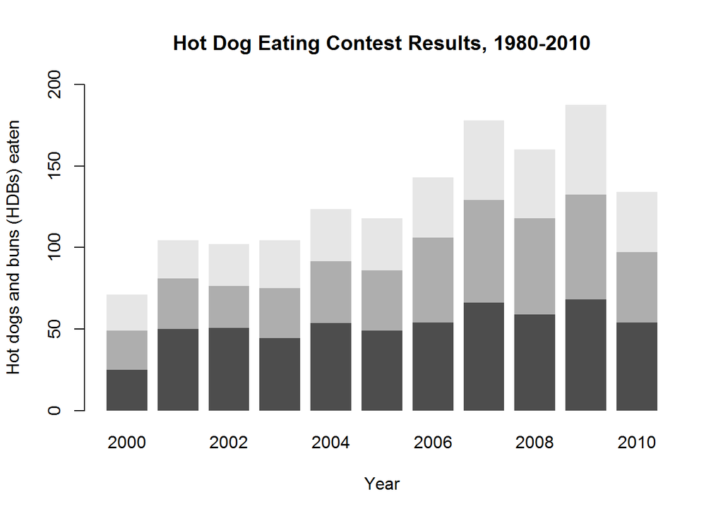

```r
hot_dog_matrix = as.matrix(hot_dog_places)

barplot(hot_dog_matrix,
        border = NA,
        space = 0.25,
        ylim = c(0,200),
        xlab = "Year",
        ylab = "Hot dogs and buns (HDBs) eaten",
        main = "Hot Dog Eating Contest Results, 1980-2010")
```

색을 바꿔보자

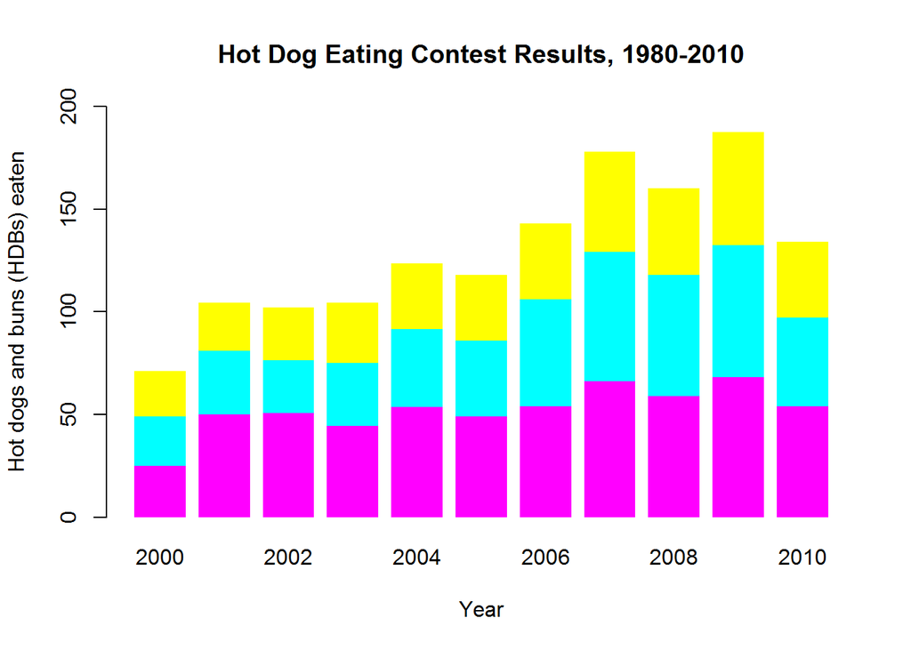

```r
barplot(hot_dog_matrix,
        border = NA,
        col = c("magenta","cyan","yellow"),
        space = 0.25,
        ylim = c(0,200),
        xlab = "Year",
        ylab = "Hot dogs and buns (HDBs) eaten",
        main = "Hot Dog Eating Contest Results, 1980-2010")
```

## 스캐터플롯

데이터부터 불러오자

```r
subscribers = read.csv("http://datasets.flowingdata.com/flowingdata_subscribers.csv",
                       sep = ",",
                       header = T)
head(subscribers)
```

```
##         Date Subscribers Reach Item.Views  Hits
## 1 01-01-2010       25047  4627       9682 27225
## 2 01-02-2010       25204  1676       5434 28042
## 3 01-03-2010       25491  1485       6318 29824
## 4 01-04-2010       26503  6290      17238 48911
## 5 01-05-2010       26654  6544      16224 45521
## 6 01-06-2010       26851  6574      16717 43071
```

**Date** 날짜

**Subscribers** 구독자 수

**Reach** 접속자 수

**Item.Views** 읽은 글 수

**Hits** 접속 수

구독자 수로 그림을 그려보자

일단 위에서 설명했듯이 plot으로 그리면 산점도가 나오는게 기본이다

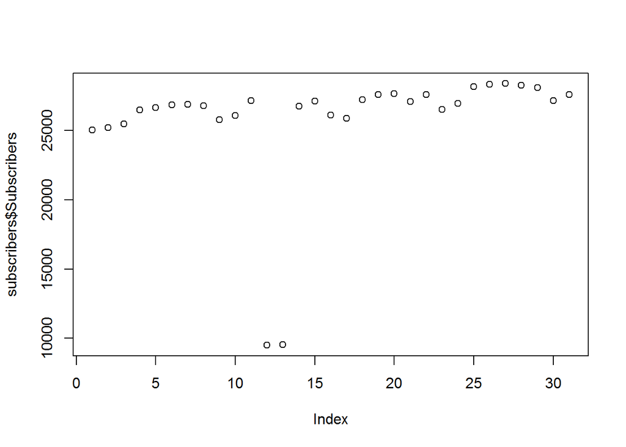

```r
plot(subscribers$Subscribers)
```

**type** 그래프 형태 : `p`는 점으로 표현되고 `h`로 하면 고밀도 수직선 그래프

ylim 을 통해 y값의 표현 범위를 정할 수 있다.

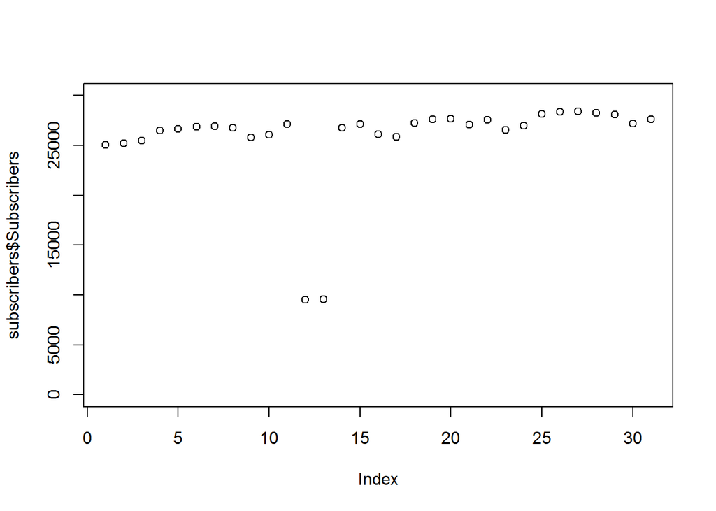

```r
plot(subscribers$Subscribers,
     type = "p",
     ylim = c(0,30000))
```

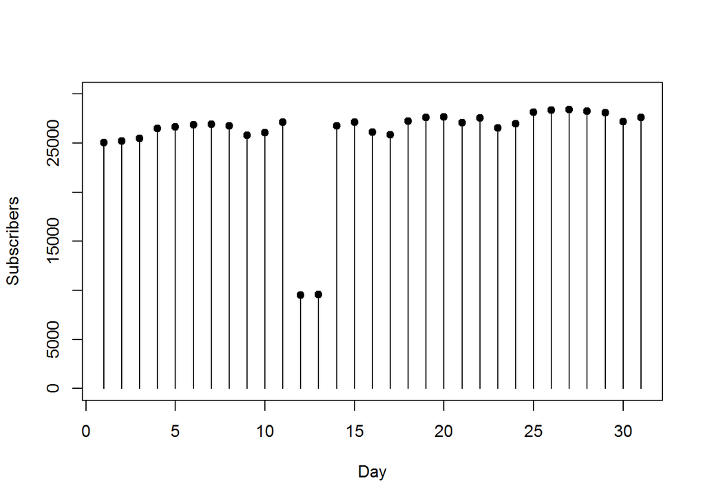

```r
plot(subscribers$Subscribers,
     type = "h",
     ylim = c(0,30000),
     xlab = "Day",
     ylab = "Subscribers")

points(subscribers$Subscribers,
       pch = 19,
       col = "black")
```

`plot`함수의 경우 실행되면 새로운 그래픽을 생성해버린다

반면 `points`,`lines`, `abline` 등의 함수는 화면에 있는 그래픽위에 내용을 덮어쓰기만 한다

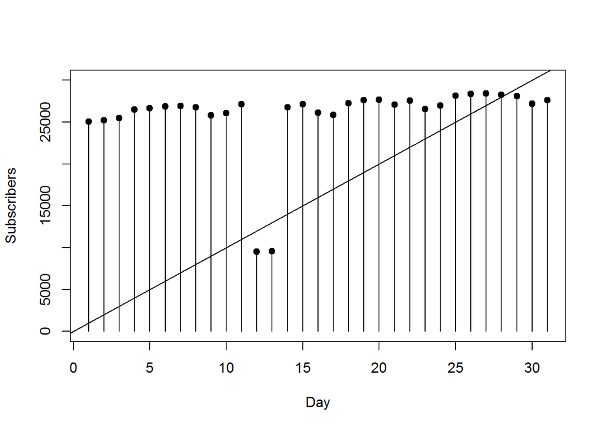

```r
plot(subscribers$Subscribers, type="h", ylim=c(0,30000), xlab="Day", ylab="Subscribers")
points(subscribers$Subscribers, pch=19, col="black")
abline(0,1000)
```

`abline` 함수는 `abline(a,b)` 로 구성되는데 y = a + bx 라고 생각하면 된다

# 연속형 데이터

## 시계열 그래프

세계은행에서 발표한 세계 인구 데이터이다

```r
population = read.csv("http://datasets.flowingdata.com/world-population.csv",
                      sep = ",",
                      header = T)
head(population)
```

```
##   Year Population
## 1 1960 3028654024
## 2 1961 3068356747
## 3 1962 3121963107
## 4 1963 3187471383
## 5 1964 3253112403
## 6 1965 3320396924
```

각각 연도와 인구를 나타낸다

`type = "l"` 을 이용해 선으로 연결할 수 있다

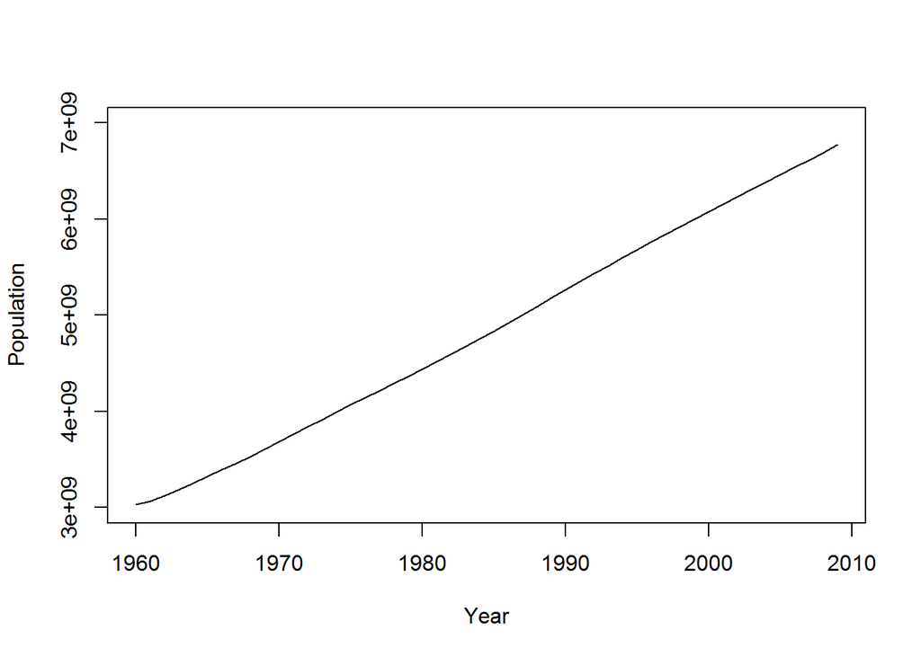

```r
plot(population$Year,population$Population,
     type = "l",
     ylim = c(3000000000, 7000000000),
     xlab = "Year",
     ylab = "Population")
```

## 계단식 그래프

미국의 우편요금 변화 기록이다

```r
postage = read.csv("http://datasets.flowingdata.com/us-postage.csv",
                   sep=",",
                   header=T)

head(postage)
```

```
##   Year Price
## 1 1991  0.29
## 2 1995  0.32
## 3 1999  0.33
## 4 2001  0.34
## 5 2002  0.37
## 6 2006  0.39
```

각각 연도와 요금(달러)이다

`type = "s"`로 계단식 그래프를 그릴 수 있다. s는 step이다 l은 line, p 는 point 겠지..

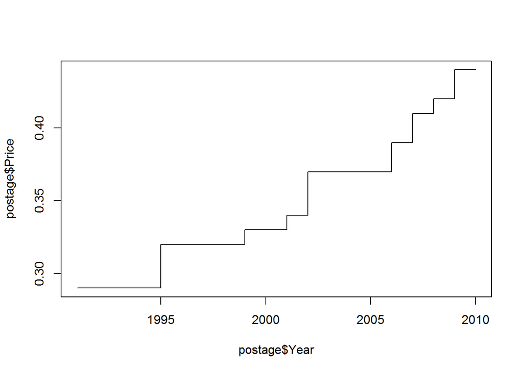

```r
plot(postage$Year, postage$Price,
     type = "s")
```

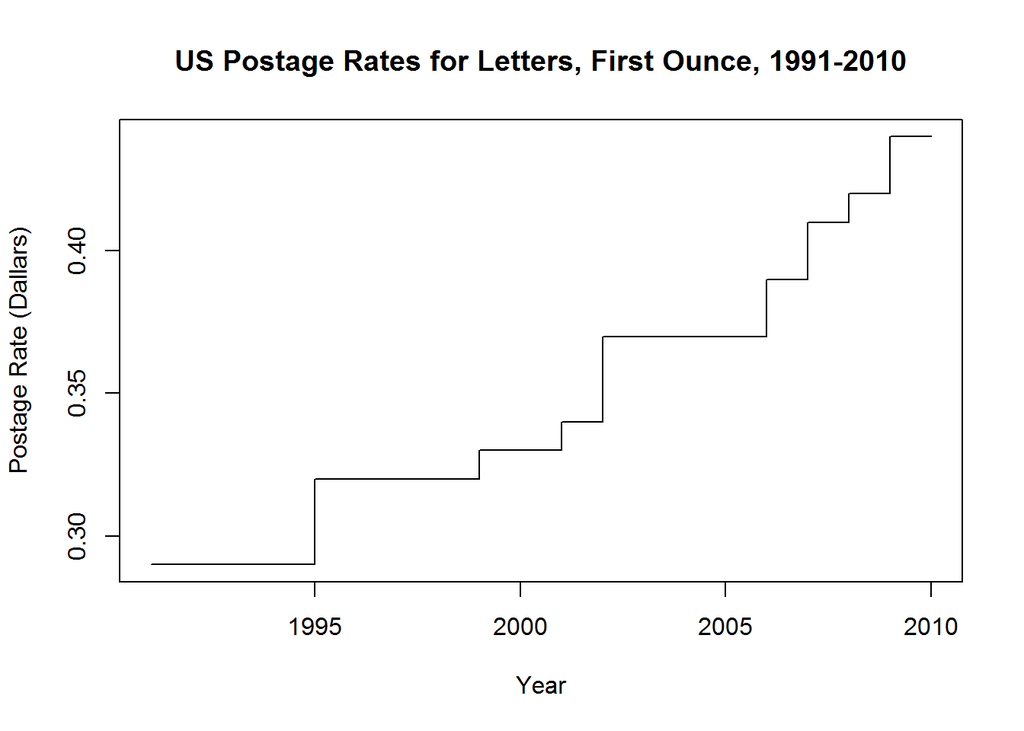

```r
plot(postage$Year, postage$Price,
     type = "s",
     main = "US Postage Rates for Letters, First Ounce, 1991-2010",
     xlab = "Year",
     ylab = "Postage Rate (Dallars)")
```

계단식 그래프를 통해 단계적으로 우편 요금이 증가하는 모습을 확인할 수 있다

그냥 선으로 이어버리면 우편요금이 일정하게 유지되는 구간을 보여줄 수 없다

## loess

**Locally Weighted ScatterPlot Smoothing** 으로 데이터의 곡률에 맞는 추세선을 그리는 방법이다

데이터를 작은 조각으로 쪼개서 각 조각마다 추세선을 만들고 종합해서 하나의 곡선 추세선을 형성한다

데이터가 곡선의 추세를 보일 때 사용하자

일단 데이터

미국 실업률 1948-2010

```r
unemployment = read.csv("http://datasets.flowingdata.com/unemployment-rate-1948-2010.csv",
                        sep=",")

head(unemployment)
```

```
##     Series.id Year Period Value
## 1 LNS14000000 1948    M01   3.4
## 2 LNS14000000 1948    M02   3.8
## 3 LNS14000000 1948    M03   4.0
## 4 LNS14000000 1948    M04   3.9
## 5 LNS14000000 1948    M05   3.5
## 6 LNS14000000 1948    M06   3.6
```

일단 직선으로 fitting한 결과이다

`lm` 은 linear model 함수인데 여기서는 직선으로 회귀식을 그렸다

intercept와 slope를 반환하기 때문에 abline에 바로 넣으면 직선 추세선을 그릴 수 있다.

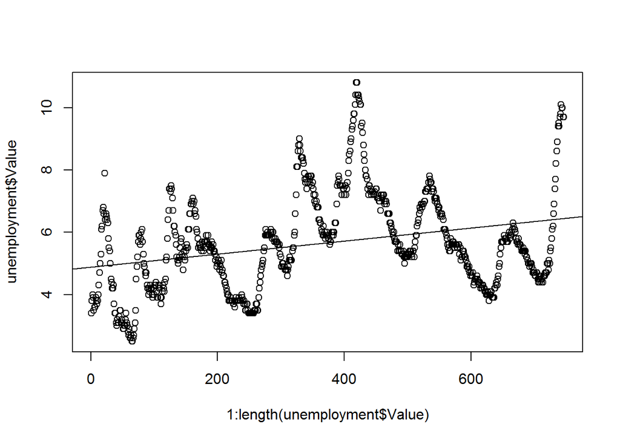

```r
plot(1:length(unemployment$Value), unemployment$Value)
lnth = 1:length(unemployment$Value)
abline(lm(unemployment$Value ~ lnth))
```

다음은 loess 추세선이다

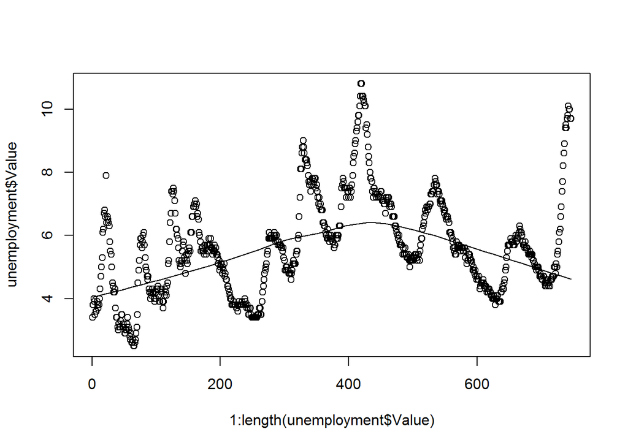

```r
scatter.smooth(x = 1:length(unemployment$Value), y = unemployment$Value)
```

degree와 span으로 곡률을 조정할 수 있다

자세한 옵션이 궁금하면 `?scatter.smooth`을 통해 살펴보자

# 분포 시각화

## 트리맵

플로잉데이터라는 저자의 블로그에서 가장 인기있는 글 100를 선정하여 카테고리별로 시각화를 하겠다고 한다

```r
posts = read.csv("http://datasets.flowingdata.com/post-data.txt")

head(posts)
```

```
##     id  views comments               category
## 1 5019 148896       28 Artistic Visualization
## 2 1416  81374       26          Visualization
## 3 1416  81374       26               Featured
## 4 3485  80819       37               Featured
## 5 3485  80819       37                Mapping
## 6 3485  80819       37           Data Sources
```

**id** 아이디

**views** 페이지뷰

**comments** 댓글

**category** 분류

포트폴리오 패키지는 원래 주식시장의 포트폴리오를 만들기 위해서 쓰는 패키지인데

트리맵 만들기가 편해서 일단 이용해본다

트리맵은 영역 기반의 시각화로, 각 사각형의 넓이가 수치를 나타낸다

위계 구조가 있는 데이터나 트리 구조의 데이터를 표시할 때 적당하다

```r
#install.packages("portfolio")
library(portfolio)
```

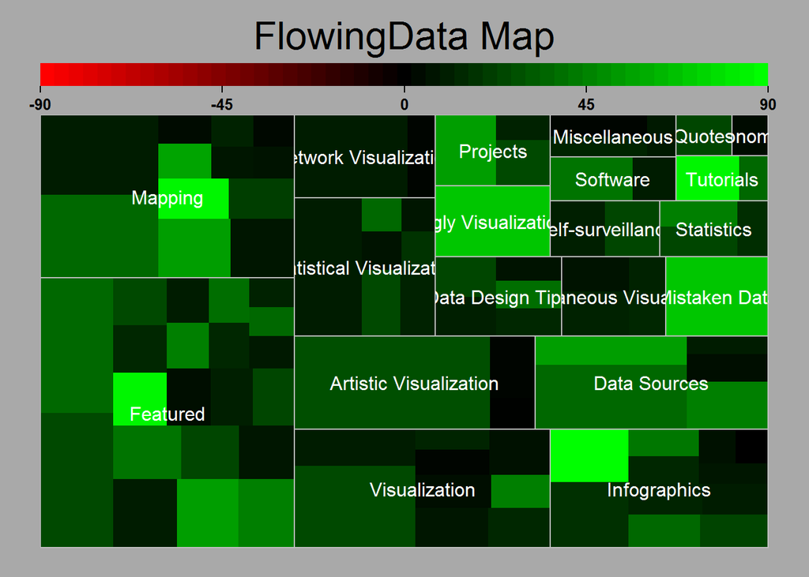

```r
map.market(id = posts$id,
           area = posts$views,
           group = posts$category,
           color = posts$comments,
           main = "FlowingData Map")
```

`id` 는 사각형으로 표시할 데이터의 접근자

`area`는 면적에 반영할 값

`group`은 사각형을 그룹으로 묶는데 사용되고

`color`를 이용해 댓글 열에 따라서 구분한다

# 파이 차트

Visualize This에 내용이 없어서 추가했다

## Simple Pie Chart

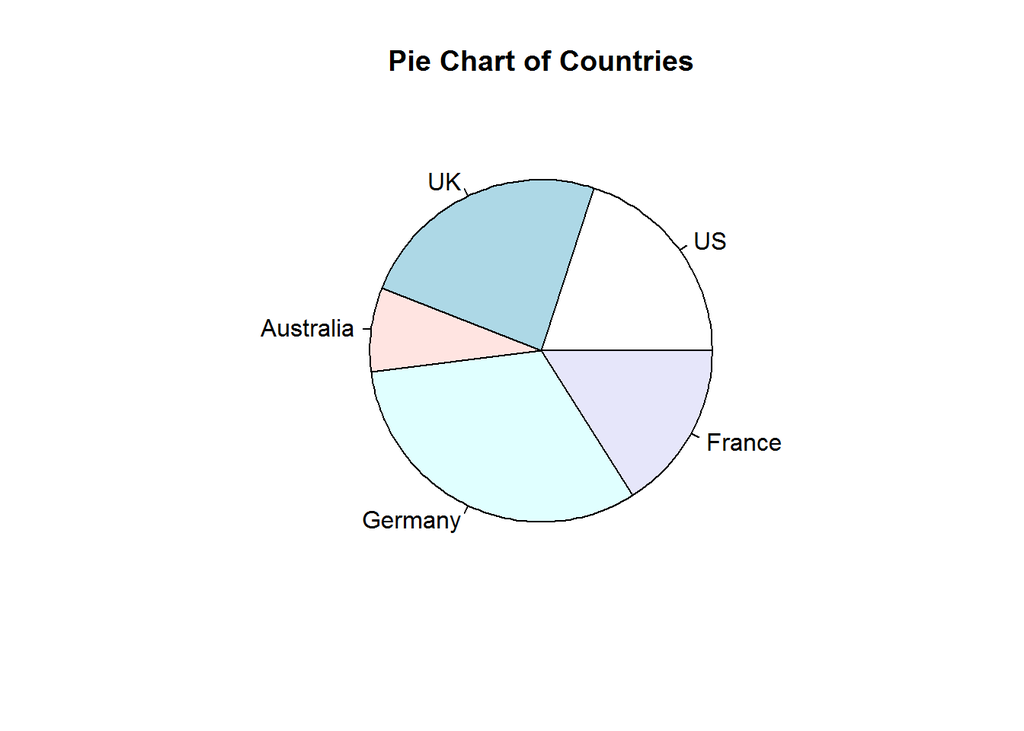

```r
slices <- c(10, 12,4, 16, 8)
lbls <- c("US", "UK", "Australia", "Germany", "France")
pie(slices, labels = lbls, main="Pie Chart of Countries")
```

## Pie Chart with Percentages

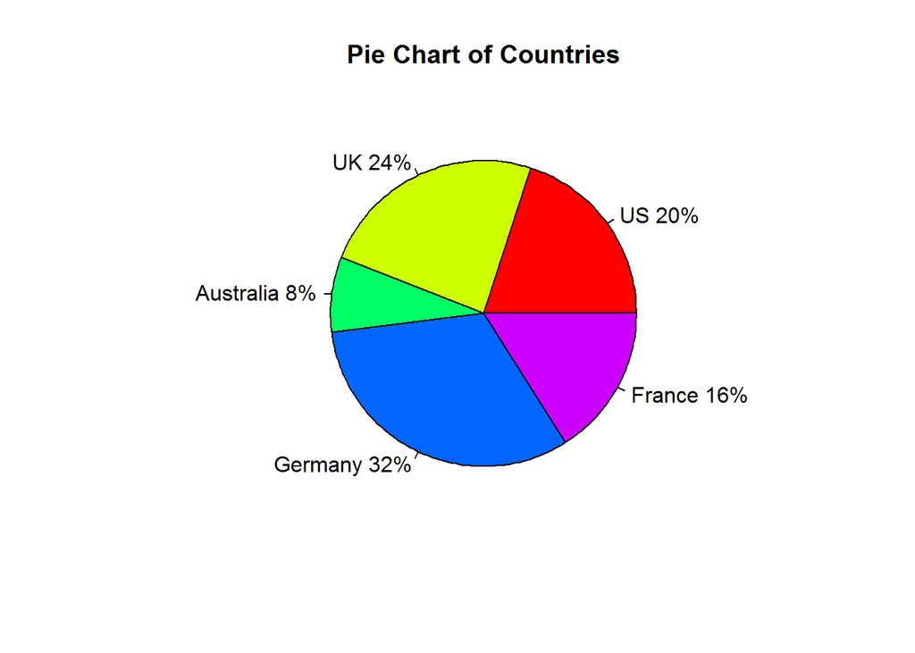

```r
slices <- c(10, 12, 4, 16, 8)

lbls <- c("US", "UK", "Australia", "Germany", "France")

pct <- round(slices / sum(slices) * 100)

lbls <- paste(lbls, pct) # add percents to labels

lbls <- paste(lbls,"%",sep="") # ad % to labels

pie(slices,
    labels = lbls,
    col = rainbow(length(lbls)),
    main = "Pie Chart of Countries")
```

## Pie Chart from data frame with Appended Sample Sizes

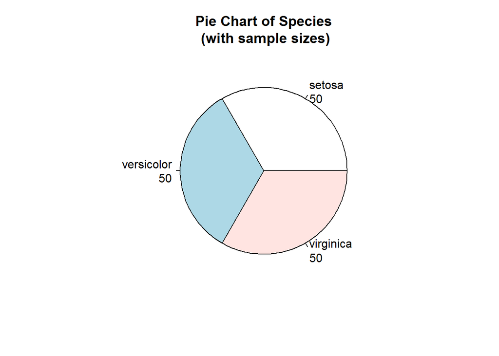

```r
mytable <- table(iris$Species)

lbls <- paste(names(mytable), "\n", mytable, sep="")

pie(mytable,
    labels = lbls,
    main = "Pie Chart of Species\n (with sample sizes)")
```

# 관계 시각화

## Scatter Plot

다음 데이터는 미국의 2005년 범죄 유형별 발생건을 인구 100000명 당 발생 비율로 나타낸 결과이다

범죄 유형에 따라 7가지로 나뉜다 (*살인*, *절도*, *강간*, *강도*, *폭행*, *차량절도*, *절취*)

```r
crime = read.csv("http://datasets.flowingdata.com/crimeRatesByState2005.csv",
                 sep = ",",
                 header = T)

head(crime)
```

```
##           state murder forcible_rape robbery aggravated_assault burglary
## 1 United States    5.6          31.7   140.7              291.1    726.7
## 2       Alabama    8.2          34.3   141.4              247.8    953.8
## 3        Alaska    4.8          81.1    80.9              465.1    622.5
## 4       Arizona    7.5          33.8   144.4              327.4    948.4
## 5      Arkansas    6.7          42.9    91.1              386.8   1084.6
## 6    California    6.9          26.0   176.1              317.3    693.3
##   larceny_theft motor_vehicle_theft population
## 1        2286.3               416.7  295753151
## 2        2650.0               288.3    4545049
## 3        2599.1               391.0     669488
## 4        2965.2               924.4    5974834
## 5        2711.2               262.1    2776221
## 6        1916.5               712.8   35795255
```

일단 살인과 절도 항목에 대해서만 비교해보자

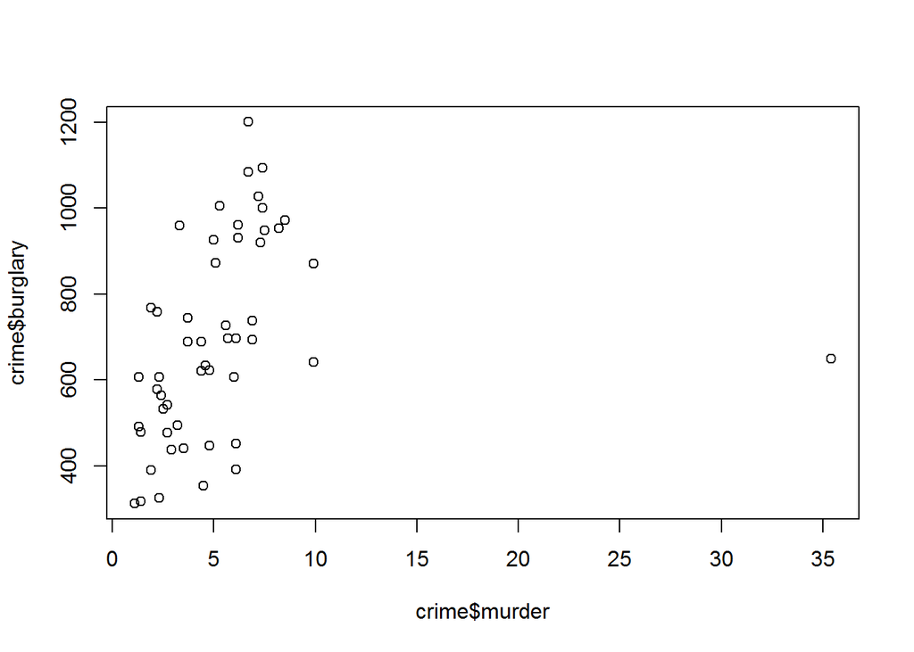

```r
plot(crime$murder, crime$burglary) #살인에 대한 절도 범죄 건수
```

오른쪽 끝의 아웃라이어 때문에 상관관계를 보기가 힘들다

워싱턴DC인데 빼고나서 확인해보자

미국 전체에 대한 항목도 빼버린다

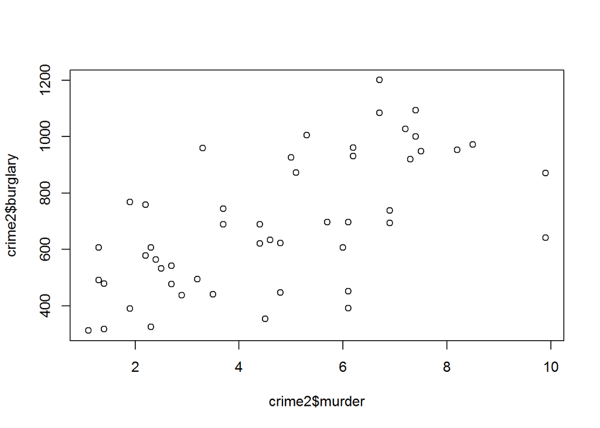

```r
crime2 = crime[crime$state != "District of Columbia",] #아웃라이어를 일단 제거하고 해보자
crime2 = crime2[crime2$state != "United States",] #미국 전체 데이터도 제거

plot(crime2$murder, crime2$burglary)
```

축이 0부터 시작하는게 좋은 것 같다

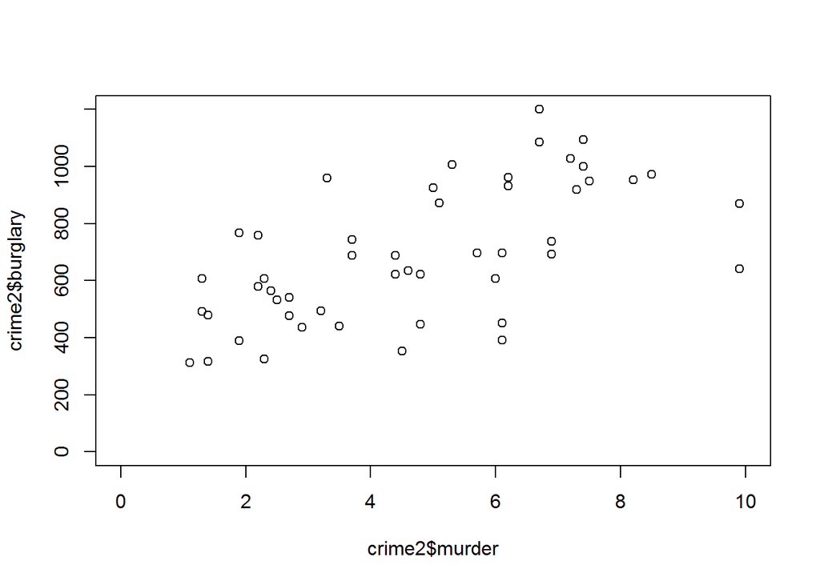

```r
plot(crime2$murder, crime2$burglary,
     xlim = c(0,10),
     ylim = c(0,1200))
```

절도와 살인 발생 비율의 관계를 분명하게 확인하기 위해 추세선을 그려보자

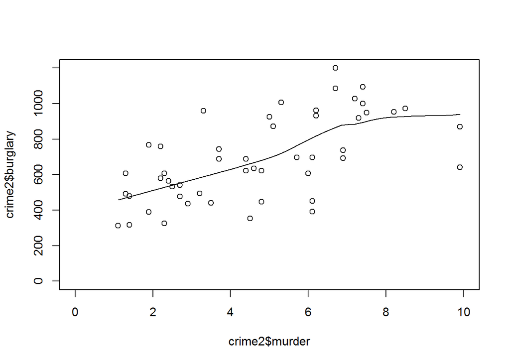

```r
scatter.smooth(crime2$murder, crime2$burglary,
               xlim = c(0,10),
               ylim = c(0,1200))
```

## Scatter Plot matrix

위에서 두 개 변수 사이의 관계를 봤으니 이번에는 여러 변수의 관계를 보고싶다

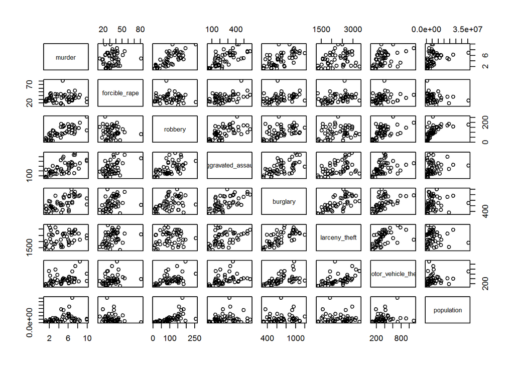

```r
plot(crime2[,2:9])
```

주의 이름을 나타내는 열을 빼고 전부 `plot`에 넣었더니 이렇게 뽑아준다

추세선을 넣어보자

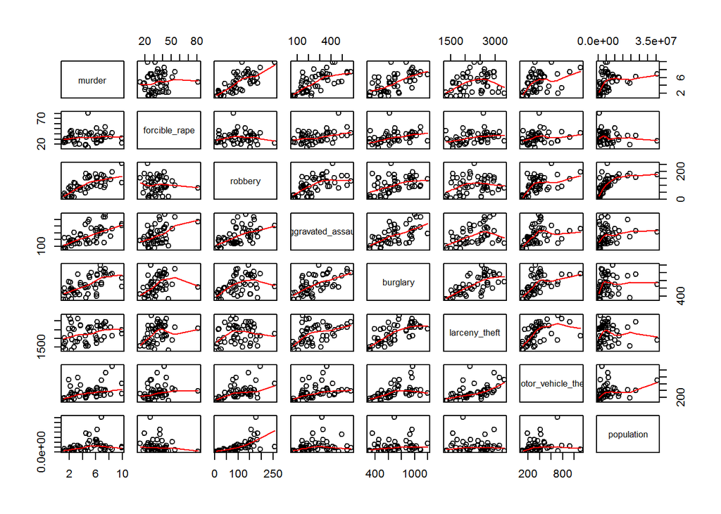

```r
pairs(crime2[,2:9],
      panel = panel.smooth)
```

panel 인수는 x, y에 대한 함수를 변수로 받아 전달한다

예제 코드에선 panel.smooth() 함수(LOESS 추세선을 그려주는 함수)를 전달했다.

자신이 만든 함수도 넣을 수 있다

## Burble Chart

스캐터플롯에 버블의 크기로 세 번째 변수를 나타내는 그래프이다

주의해야할 점은 세번째 변수의 값은 반지름이나 지름이 아니라 **면적**으로 표현되어야 한다

```r
crime = read.csv("http://datasets.flowingdata.com/crimeRatesByState2005.tsv",
                 header = T,
                 sep = "\t")
```

앞에 있던 예제와 거의 같은 데이터이다

쉼표 대신 탭으로 구분하는 tsv 파일이므로 구분자를 `\t`로 변경해주자

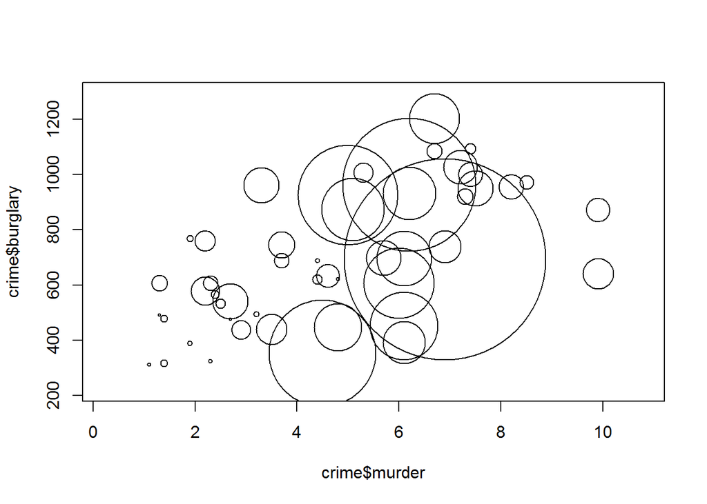

```r
symbols(crime$murder, crime$burglary,
        circles = crime$population)
```

반지름에 데이터가 들어가니 원이 너무 커진다

원의 면적을 통해 데이터를 표현하자

**원의 면적** : pi * r^2

**r = sqrt(원의면적/pi)** 여기서는 비례를 구하려는 것이니 파이는 무시해도 된다

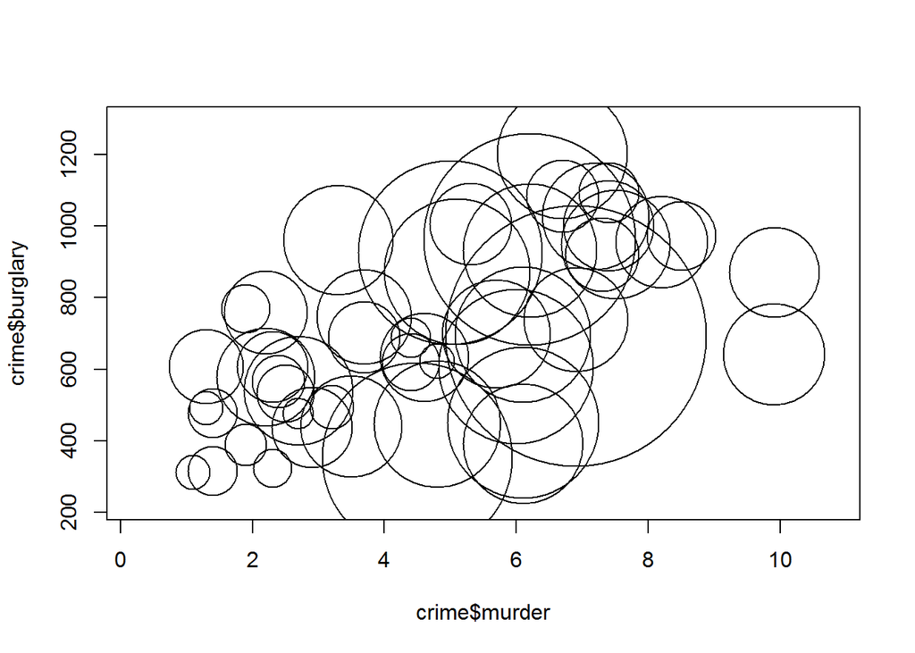

```r
radius = sqrt(crime$population / pi)

symbols(crime$murder, crime$burglary,
        circles = radius) #음.... 원이 전체적으로 다 커보인다
```

모든 원의 크기를 전체적으로 줄일 필요가 있는것같다

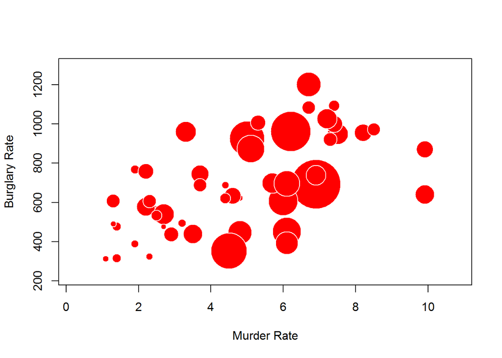

```r
symbols(crime$murder, crime$burglary,
        circles = radius,
        inches = 0.35,
        fg = "white",
        bg = "red",
        xlab = "Murder Rate",
        ylab = "Burglary Rate")
```

**inches** : 가장 큰원의 크기를 inch 단위로 설정

**fg** : foreground

**bg** : background

symbols 함수는 다른 모형을 선택할 수도 있다.

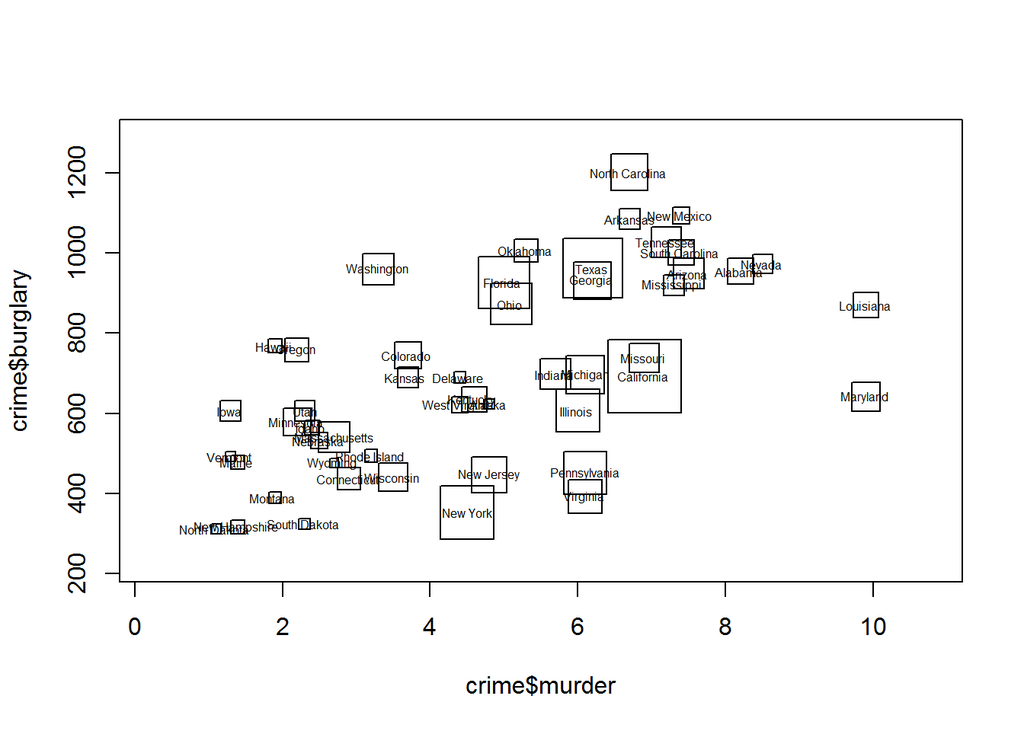

```r
symbols(crime$murder,crime$burglary,
        squares = sqrt(crime$population),
        inches = 0.5)

text(crime$murder, crime$burglary, crime$state,
     cex = 0.5)
```

정사각형 `square` 직사각형 `rectangles` 써모미터 `thermometers` 박스플롯 `boxplots` 별 `stars` 등이 선택가능하다

자세한 것은 `?symbols`

cex 는 출력 문구의 크기이다 (기본값 1)

# 히스토그램

데이터는 2002년부터 2009년까지 TV크기 분포 그래프이다

참 신기한 데이터가 많다

```r
tvs=read.table("http://datasets.flowingdata.com/tv_sizes.txt",
               sep = "\t",
               header = T)
```

아웃라이어를 제거한다

```r
tvs=tvs[tvs$size <80,]
tvs=tvs[tvs$size >10,]
```

히스토그램 구간 수를 설정한다

```r
breaks = seq(10, 80, by=5)
```

레이아웃을 설정하고 차트를 그린다

4,2 니깐 4행에 2열 짜리

[figure not shown]

```r
par(mfrow=c(4,2))
hist(tvs[tvs$year == 2009,]$size, breaks=breaks)
hist(tvs[tvs$year == 2008,]$size, breaks=breaks)
hist(tvs[tvs$year == 2007,]$size, breaks=breaks)
hist(tvs[tvs$year == 2006,]$size, breaks=breaks)
hist(tvs[tvs$year == 2005,]$size, breaks=breaks)
hist(tvs[tvs$year == 2004,]$size, breaks=breaks)
hist(tvs[tvs$year == 2003,]$size, breaks=breaks)
hist(tvs[tvs$year == 2002,]$size, breaks=breaks)
```

```r
par(mfrow=c(1,1)) # 이건 그냥 디폴트 설정으로 돌리기 위해서
```